# Class 3 Example regarding 2017 Survey Data

Thomas E. Love

Generated 2017-09-05

```r
knitr::opts_chunk$set(comment=NA)
options(width = 70)

library(magrittr); library(tidyverse)
## make sure these libraries are installed in R
```

```r
sur_day1 <- read.csv("surveyday1_2017.csv") %>% tbl_df()

sur_day1
```

```
# A tibble: 203 x 20
   student    sex english statsofar ageguess smoke h.left h.right
     <int> <fctr>  <fctr>     <int>    <int> <int>  <int>   <int>
 1  201701      m       y         3       52     1     15       3
 2  201702      m       y         5       48     1     12       5
 3  201703      f       y         3       55     1      0      20
 4  201704      m       y         6       55     1     14       3
 5  201705      m       y         4       50     1      1      18
 6  201706      m       y         4       44     1      3      14
 7  201707      m       y         5       45     1      2      13
 8  201708      m       y         4       50     1      0      20
 9  201709      m       y         5       48     1      4       7
10  201710      f       y         5       55     1      2      10
# ... with 193 more rows, and 12 more variables: handedness <dbl>,
#   statfuture <int>, haircut <dbl>, lecture <int>, alone <int>,
#   height.in <dbl>, hand.span <dbl>, favcolor <fctr>,
#   lastsleep <dbl>, pulse <int>, year <int>, lovetrueage <dbl>
```

# The variables we’re studying today

```r
sur_day1 %>%
    select(year, sex, favcolor, haircut, ageguess, pulse, lastsleep) %>%
    summary()
```

```
      year      sex        favcolor     haircut          ageguess
 Min.   :2014   f: 96   blue   :80   Min.   :  0.00   Min.   :24.00
 1st Qu.:2015   m:107   green  :32   1st Qu.: 12.00   1st Qu.:43.00
 Median :2016           red    :17   Median : 20.00   Median :47.00
 Mean   :2016           purple :15   Mean   : 24.53   Mean   :46.67
 3rd Qu.:2016           pink   : 7   3rd Qu.: 30.00   3rd Qu.:50.00
 Max.   :2017           (Other):49   Max.   :210.00   Max.   :70.00
                        NA's   : 3   NA's   :2        NA's   :4
     pulse          lastsleep
 Min.   : 30.00   Min.   :2.000
 1st Qu.: 64.00   1st Qu.:6.000
 Median : 70.00   Median :7.000
 Mean   : 72.18   Mean   :6.988
 3rd Qu.: 80.00   3rd Qu.:8.000
 Max.   :106.00   Max.   :9.500
 NA's   :1        NA's   :2
```

So we have missing values in the `favcolor`, `haircut`, `ageguess`, `pulse` and `lastsleep` data to watch out for.

# What are the favorite colors of students in 431?

First, we’ll try the `summary` function.

```r
sur_day1 %>%
    select(favcolor) %>%
    summary()
```

```
    favcolor
 blue   :80
 green  :32
 red    :17
 purple :15
 pink   : 7
 (Other):49
 NA's   : 3
```

Perhaps a `table` would be more useful here, since the data are categorical.

```r
sur_day1 %>%
    select(favcolor) %>%
    table()
```

```
.
        aqua   aquamarine        black         blue        brown
           2            1            4           80            3
burnt orange   chartreuse    dark blue      depends         gray
           1            1            2            1            2
       green         grey   light blue         navy         none
          32            4            1            2            2
      orange         pink       purple          red   royal blue
           4            7           15           17            1
    sapphire       silver         teal    turquoise       violet
           1            1            1            1            1
       white       yellow
           6            7
```

It might be nice to see that table just for the 2017 data.

```r
sur_day1 %>%
    filter(year == 2017) %>%
    select(favcolor) %>%
    table()
```

```
.
        aqua   aquamarine        black         blue        brown
           0            0            1           18            0
burnt orange   chartreuse    dark blue      depends         gray
           1            0            0            0            1
       green         grey   light blue         navy         none
           9            1            0            0            1
      orange         pink       purple          red   royal blue
           1            2            4            4            0
    sapphire       silver         teal    turquoise       violet
           0            0            0            1            0
       white       yellow
           1            3
```

Let’s drop the levels with zeros, and add a total.

```r
sur_day1 %>%
    filter(year == 2017) %>%
    select(favcolor) %>%
    droplevels() %>%
    table() %>%
    addmargins()
```

```
.
       black         blue burnt orange         gray        green
           1           18            1            1            9
        grey         none       orange         pink       purple
           1            1            1            2            4
         red    turquoise        white       yellow          Sum
           4            1            1            3           48
```

Another approach that creates a tibble with the counts, so that we can arrange them in descending order from most common to least common?

```r
sur_day1 %>%
    filter(year == 2017) %>%
    group_by(favcolor) %>%
    count() %>%
    arrange(desc(n))
```

```
# A tibble: 14 x 2
# Groups:   favcolor [14]
       favcolor     n
         <fctr> <int>
 1         blue    18
 2        green     9
 3       purple     4
 4          red     4
 5       yellow     3
 6         pink     2
 7        black     1
 8 burnt orange     1
 9         gray     1
10         grey     1
11         none     1
12       orange     1
13    turquoise     1
14        white     1
```

## A more challenging question

What is the percentage of students who prefer `blue` in each year?

```r
sur_day1 %>%
    group_by(year) %>%
    summarize(blue_count = sum(favcolor == "blue", na.rm=TRUE),
              total_count = sum(!is.na(favcolor)),
              blue_percent = round(100 * blue_count / total_count, 1))
```

```
# A tibble: 4 x 4
   year blue_count total_count blue_percent
  <int>      <int>       <int>        <dbl>
1  2014         15          40         37.5
2  2015         20          48         41.7
3  2016         27          64         42.2
4  2017         18          48         37.5
```

# What price did students in 431 pay for a haircut?

Let’s summarize this graphically first. Perhaps a histogram?

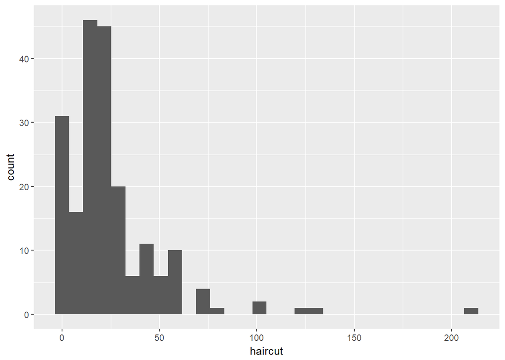

```r
ggplot(data = sur_day1, aes(x = haircut)) +
    geom_histogram()
```

## Improving the Histogram

Let’s change the fill and color, and specify the size of the bins to be $10.

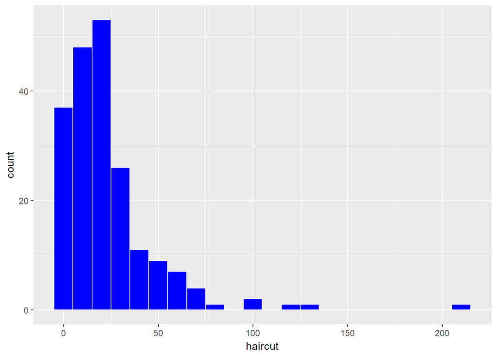

```r
ggplot(data = sur_day1, aes(x = haircut)) +
    geom_histogram(binwidth = 10,
                   fill = "blue", color = "white")
```

Can we improve the labels?

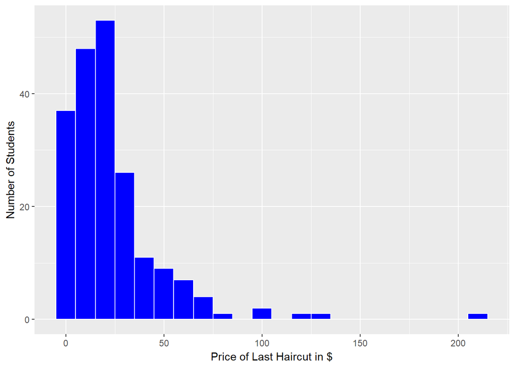

```r
ggplot(data = sur_day1, aes(x = haircut)) +
    geom_histogram(binwidth = 10,
                   fill = "blue", color = "white") +
    labs(x = "Price of Last Haircut in $",
         y = "Number of Students")
```

Can we eliminate that missing values issue?

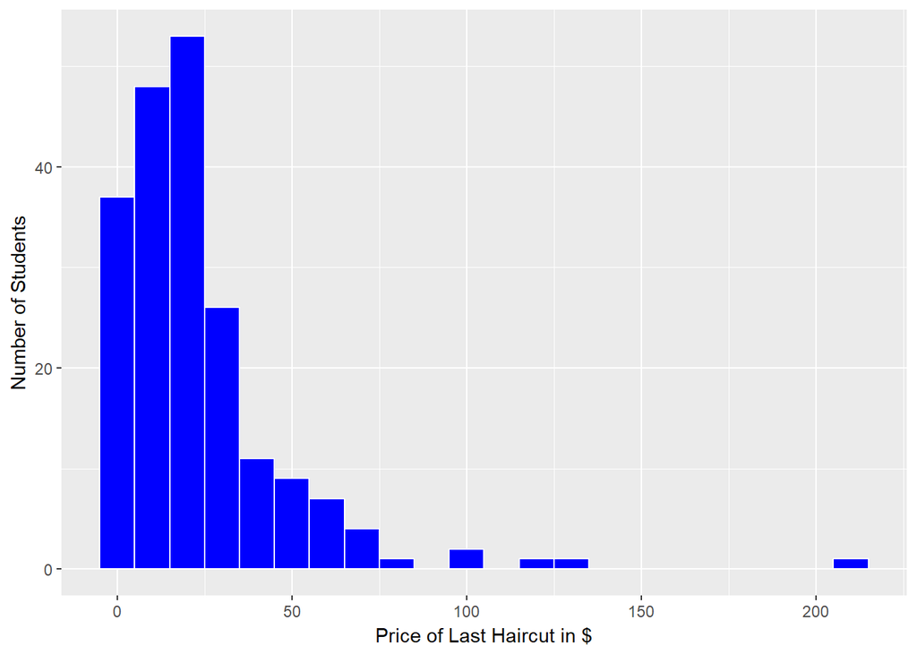

```r
sur_day1 %>%
    filter(!is.na(haircut)) %>%
ggplot(., aes(x = haircut)) +
    geom_histogram(binwidth = 10, fill = "blue", color = "white") +
    labs(x = "Price of Last Haircut in $", y = "Number of Students")
```

## Numerical Summary

```r
sur_day1 %>%
    select(haircut) %>%
    summary()
```

```
    haircut
 Min.   :  0.00
 1st Qu.: 12.00
 Median : 20.00
 Mean   : 24.53
 3rd Qu.: 30.00
 Max.   :210.00
 NA's   :2
```

An alternative approach, using the `favstats` function from the `mosaic` package, and the `%$%` pipe rather than the usual `$>$`:

```r
sur_day1 %$% mosaic::favstats(haircut)
```

```
 min Q1 median Q3 max     mean       sd   n missing
   0 12     20 30 210 24.52985 25.10506 201       2
```

Or, you could use the `$` notation, as:

```r
mosaic::favstats(sur_day1$haircut)
```

```
 min Q1 median Q3 max     mean       sd   n missing
   0 12     20 30 210 24.52985 25.10506 201       2
```

## A more challenging question: Haircut Prices by Year

Can we build a separate plot for each year?

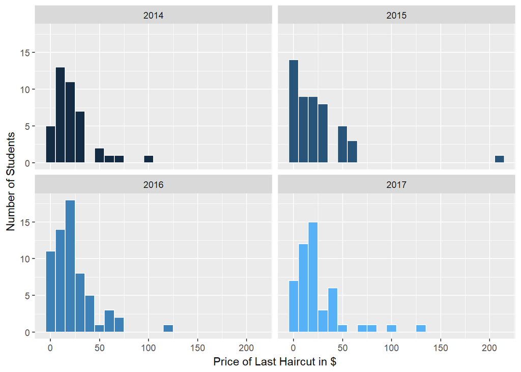

```r
sur_day1 %>%
    filter(!is.na(haircut)) %>%
    ggplot(., aes(x = haircut, fill = year)) +
        geom_histogram(binwidth = 10, color = "white") +
        guides(fill = FALSE) +
        labs(x = "Price of Last Haircut in $", y = "Number of Students") +
        facet_wrap(~ year)
```

Or we could use a boxplot instead, but this requires us to get R to see year as a factor…

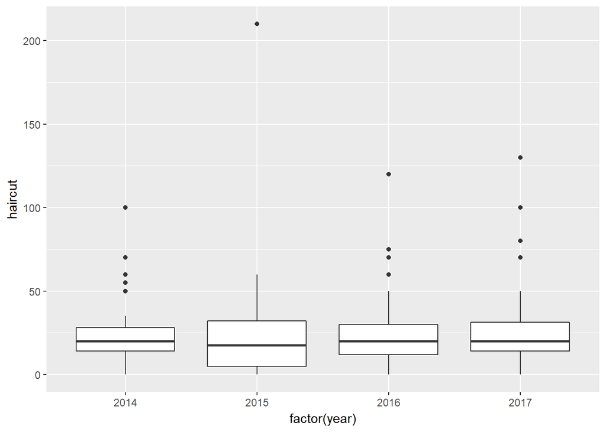

```r
ggplot(sur_day1, aes(y = haircut, x = factor(year))) +
    geom_boxplot()
```

Numerical Summary by Year?

```r
sur_day1 %>%
    filter(!is.na(haircut)) %>%
    group_by(year) %>%
    summarize(mean = mean(haircut), sd = sd(haircut), median = median(haircut))
```

```
# A tibble: 4 x 4
   year     mean       sd median
  <int>    <dbl>    <dbl>  <dbl>
1  2014 23.70732 19.81571   20.0
2  2015 24.74490 32.79992   17.5
3  2016 23.82540 21.47132   20.0
4  2017 25.93750 25.25058   20.0
```

# What is the relationship between sex and 431 students’ guess of my age?

Here’s a starting plot.

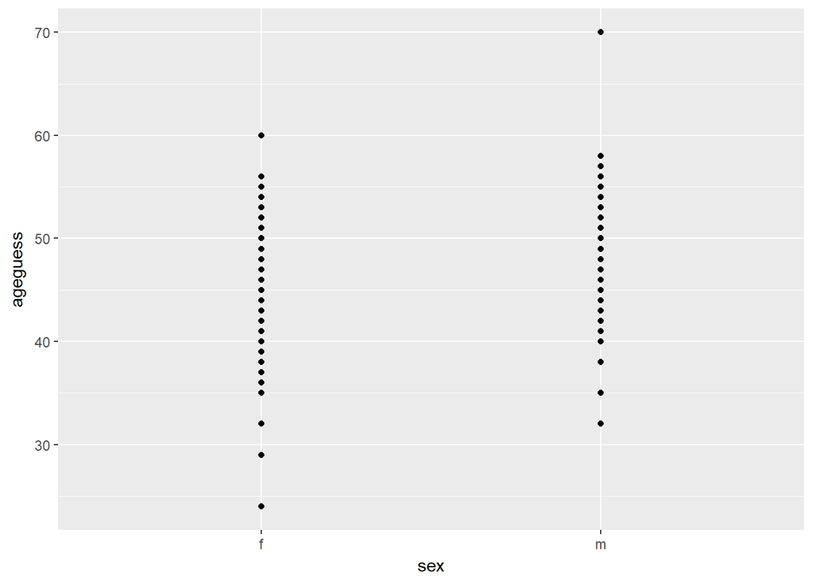

```r
sur_day1 %>%
    filter(!is.na(ageguess)) %>%
ggplot(., aes(x = sex, y = ageguess)) +
    geom_point()
```

Let’s restrict to 2017, color the points, and jitter them left-to-right a bit.

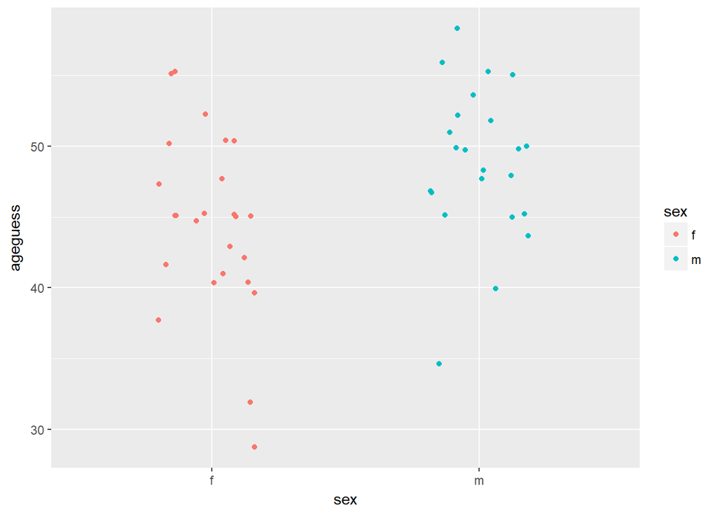

```r
sur_day1 %>%
    filter(!is.na(ageguess), year == "2017") %>%
ggplot(., aes(x = sex, y = ageguess, col = sex)) +
    geom_jitter(width = 0.2)
```

A boxplot would be the usual summary of a quantitative variable’s association with a categorical variable. We’ll add a title, too.

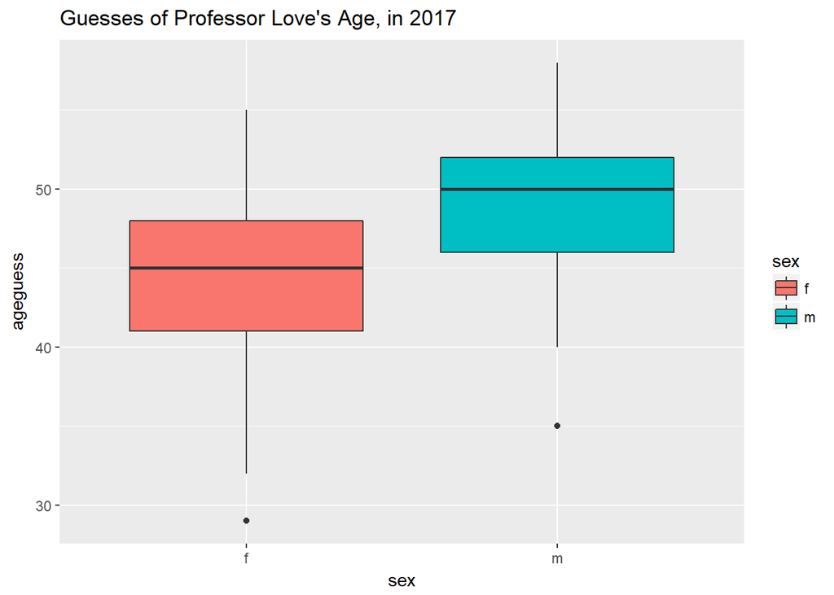

```r
sur_day1 %>%
    filter(!is.na(ageguess), year == "2017") %>%
ggplot(., aes(x = sex, y = ageguess, fill = sex)) +
    geom_boxplot() +
    labs(title = "Guesses of Professor Love's Age, in 2017")
```

We might look at faceted histograms instead.

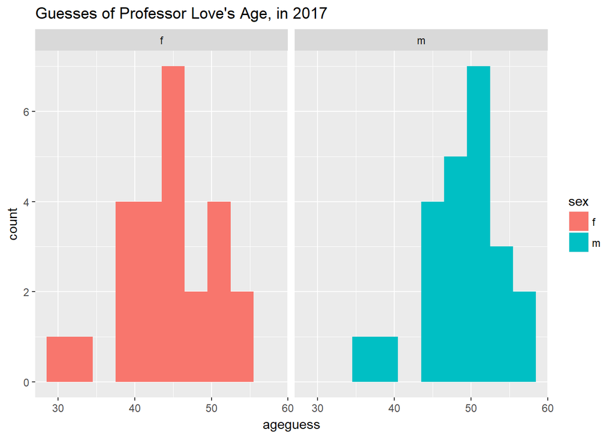

```r
sur_day1 %>%
    filter(!is.na(ageguess), year == "2017") %>%
ggplot(., aes(x = ageguess, fill = sex)) +
    geom_histogram(binwidth = 3) +
    facet_wrap(~ sex) +
    labs(title = "Guesses of Professor Love's Age, in 2017")
```

In the course notes, we’ll also explore a joy plot in this setting.

# What is the relationship between 431 students’ pulse rate and hours of sleep?

Here, we’re looking at two quantitative variables. A scatterplot is usually the best choice.

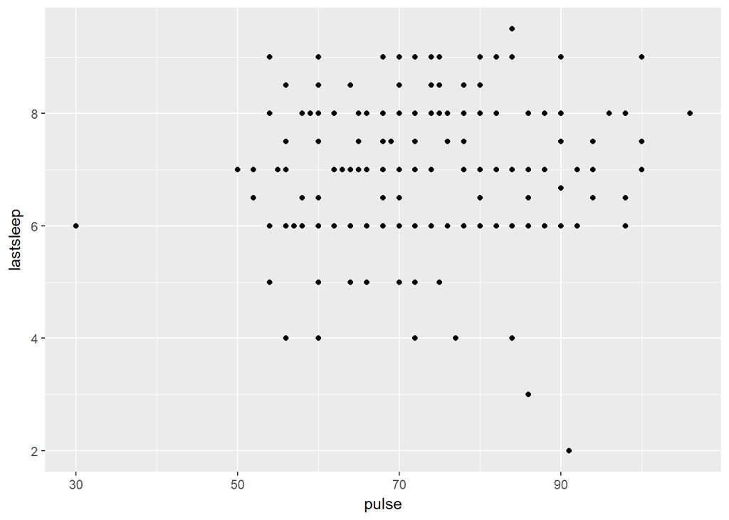

```r
ggplot(data = sur_day1, aes(x = pulse, y = lastsleep)) +
    geom_point()
```

Let’s look at the 2017 data only, and fit a model to predict last sleep on the basis of pulse rate.

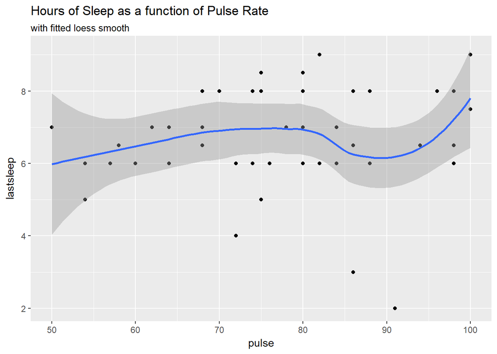

```r
sur_day1 %>%
    filter(year == "2017") %>%
    ggplot(., aes(x = pulse, y = lastsleep)) +
    geom_point() +
    geom_smooth(method = "loess") +
    labs(title = "Hours of Sleep as a function of Pulse Rate",
         subtitle = "with fitted loess smooth")
```

We could instead restrict ourselves to a linear model for last sleep on the basis of pulse rate.

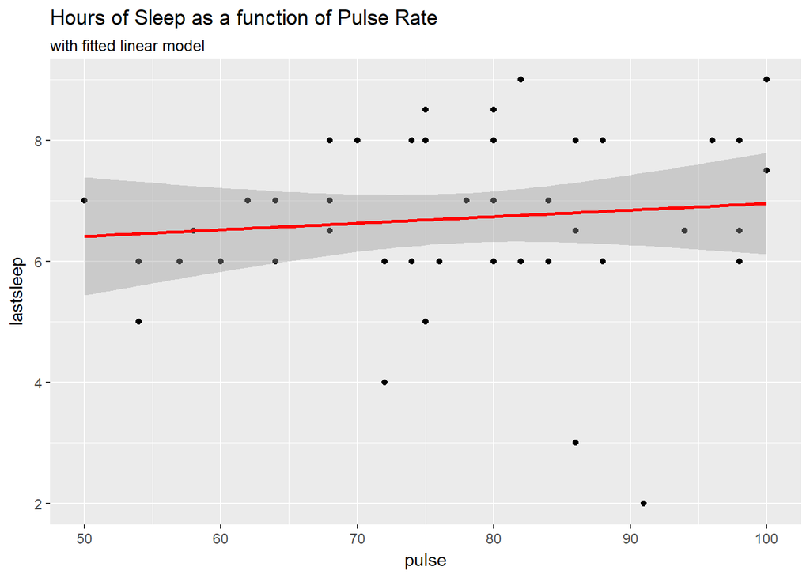

```r
sur_day1 %>%
    filter(year == "2017") %>%
    ggplot(., aes(x = pulse, y = lastsleep)) +
    geom_point() +
    geom_smooth(method = "lm", col = "red") +
    labs(title = "Hours of Sleep as a function of Pulse Rate",
         subtitle = "with fitted linear model")
```

The correlation of `lastsleep` and `pulse` is likely to be of some interest. Note the use of both the `%>%` and `%$%` pipes in this case.

```r
sur_day1 %>%
    filter(year == "2017") %$%
    cor(pulse, lastsleep)
```

```
[1] 0.09888954
```

## Does the linear model change much by year?

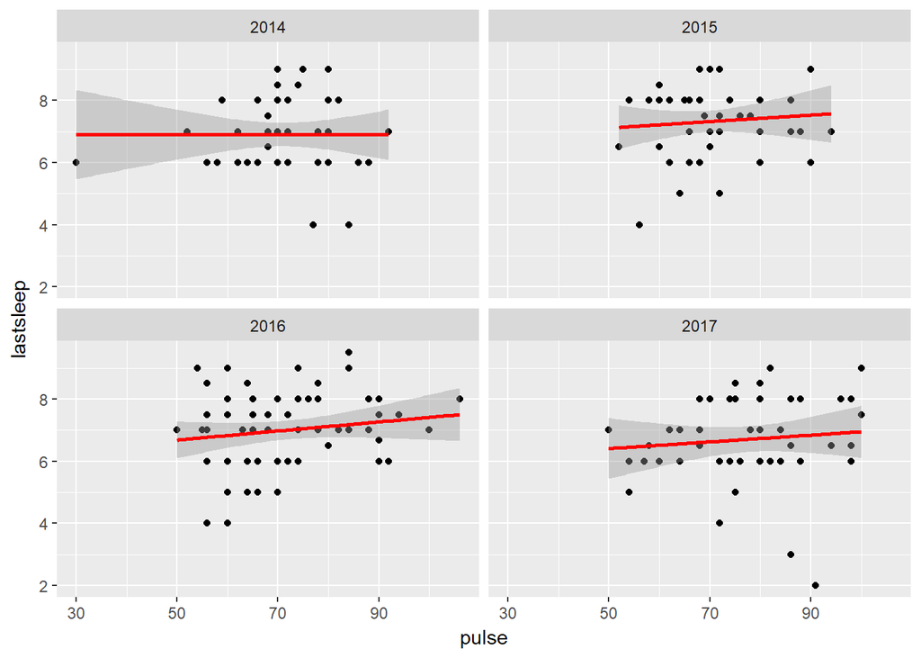

```r
sur_day1 %>%
    filter(!is.na(pulse), !is.na(lastsleep)) %>%
    ggplot(., aes(x = pulse, y = lastsleep, group = factor(year))) +
    geom_point() +
    geom_smooth(method = "lm", color = "red") +
    facet_wrap(~ year)
```